# Graphing Vangard Funds Using R

**Usage Notes**

- System setup:
  - Install `quarto` executable from https://quarto.org
- To compile report:
  - Inside RStudio: press `Render` from a recent version of RStudio

Author: Rick Dean

Article date: July 3, 2022

Abstract

Taking a handful of Vanguard mutual funds perform data wrangling and graphing of adjusted closing prices using the R language.

## Load the Required R Packages

```r
library(data.table, quietly = T)
library(ggplot2, quietly = T)
library(RplotterPkg, quietly = T)
library(riingo, quietly = T)
library(here, quietly = T)
```

## Vanguard Index Fund Closing Prices

### Select the Vanguard index funds

The following funds are selected for graphing.

**Bonds**:

[VBILX](https://investor.vanguard.com/investment-products/mutual-funds/profile/vbilx) – Inter-Term Bond Index Fund Admiral Shares

[VBIRX](https://investor.vanguard.com/investment-products/mutual-funds/profile/vbirx) – Vanguard Short-Term Bond Index Fund Admiral Shares

**Growth**:

[VIMAX](https://investor.vanguard.com/investment-products/mutual-funds/profile/vimax) – Vanguard Mid-Cap Index Fund Admiral Shares

[VFIAX](https://investor.vanguard.com/investment-products/mutual-funds/profile/vfiax) – Vanguard 500 Index Fund Admiral Shares

[VIGAX](https://investor.vanguard.com/investment-products/mutual-funds/profile/vigax) – Vanguard Growth Index Fund Admiral Shares

[VTSAX](https://investor.vanguard.com/investment-products/mutual-funds/profile/vtsax) – Vanguard Total Stock Market Index Fund Admiral Shares

**Balanced-Income-Value**

[VWELX](https://investor.vanguard.com/investment-products/mutual-funds/profile/vwelx) – Vanguard Wellington Fund Investor Shares

[VWINX](https://investor.vanguard.com/investment-products/mutual-funds/profile/vwinx) – Vanguard Wellesley Income Fund Investor Shares

[VVIAX](https://investor.vanguard.com/investment-products/mutual-funds/profile/vviax) – Vanguard Value Index Fund Admiral Shares

**Sector-Foreign**

[VGSLX](https://investor.vanguard.com/investment-products/mutual-funds/profile/vgslx) – Vanguard Real Estate Index Fund Admiral Shares

[VGHCX](https://investor.vanguard.com/investment-products/mutual-funds/profile/vghcx) – Vanguard Health Care Fund Investor Shares

[VFWAX](https://investor.vanguard.com/investment-products/mutual-funds/profile/vfwax) – Vanguard FTSE All-World ex-US Index Fund Admiral Shares

### Establish data source

Use [Tingo API](https://api.tiingo.com/) as the data source for closing prices. Read the Tingo key and establish a connection with the API:

```r
riingo::riingo_set_token(RtsaPkg::read_tingo_key())
```

### Define the tickers and start/end times of interest

Create named vectors of ticker symbols and start/end times:

```r
tickers_v <- c(
  VBILX = "Inter-term Bond Index Adm",
  VIMAX = "Mid-Cap Index Fund Adm",
  VFIAX = "500 Index Fund Adm",
  VIGAX = "Growth Index Fund Adm",
  VTSAX = "Total Stock Market Index Adm",
  VVIAX = "Value Index Fund Adm",
  VGSLX = "Real Estate Index Fund",
  VWELX = "Wellington Fund Inv",
  VFWAX = "FTSE All World ex-US Adm",
  VGHCX = "Health Care Fund Inv",
  VBIRX = "Short-Term Bond Index Adm",
  VWINX = "Wellesley Income Fund Inv"
)

times_v <- c(
  start = "2019-01-01",
  end = "2022-05-30"
)
```

### Get the closing prices

Create a `data.table` of closing prices using `RtsaPkg::get_tiingo_stock_prices()` function:

```r
prices_dt <- RtsaPkg::get_tiingo_stock_prices(
  symbols = names(tickers_v),
  from = times_v[["start"]],
  to = times_v[["end"]],
  periodicity = "weekly"
)
```

## Growth Plots

### Define the `data.table` for growth funds

```r
growth_tickers_v <- c("VIMAX","VFIAX","VIGAX","VTSAX")
growth_dt <- prices_dt[Symbol %in% growth_tickers_v,]
growth_dt[, Symbol := factor(Symbol, levels = c("VIMAX","VFIAX","VIGAX","VTSAX"))]
growth_dt[, Title := fcase(
                       Symbol == "VIMAX", tickers_v[["VIMAX"]],
                       Symbol == "VFIAX", tickers_v[["VFIAX"]],
                       Symbol == "VIGAX", tickers_v[["VIGAX"]],
                       Symbol == "VTSAX", tickers_v[["VTSAX"]]
                     )]
growth_dt[, Title := as.factor(Title)]
```

### Plot the growth funds

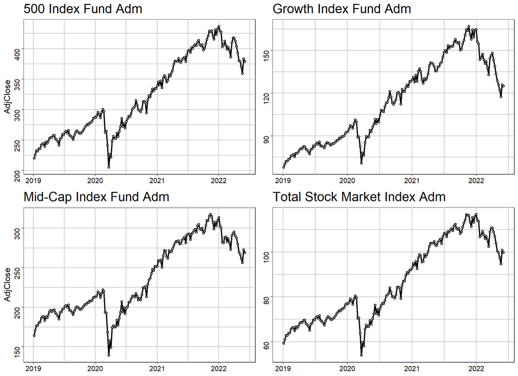

AdjClose Prices for Vanguard Growth Index Funds

```r
RplotterPkg::multi_scatter_plot(
  df = growth_dt,
  factor_var = "Title",
  factor_x = "Date",
  aes_y = "AdjClose",
  connect = TRUE,
  col_width = 5.5,
  row_height = 4
)
```

## Balanced-Income-Value Plots

### Define the `data.table` for balanced/income/value funds

```r
balanced_tickers_v <- c("VWELX","VWINX","VVIAX")
balanced_dt <- prices_dt[Symbol %in% balanced_tickers_v,]
balanced_dt[, Symbol := factor(Symbol, levels = c("VWELX","VWINX","VVIAX"))]
balanced_dt[, Title := fcase(
                       Symbol == "VWELX", tickers_v[["VWELX"]],
                       Symbol == "VWINX", tickers_v[["VWINX"]],
                       Symbol == "VVIAX", tickers_v[["VVIAX"]]
                     )]
balanced_dt[, Title := as.factor(Title)]
```

### Plot the balanced/income/value funds

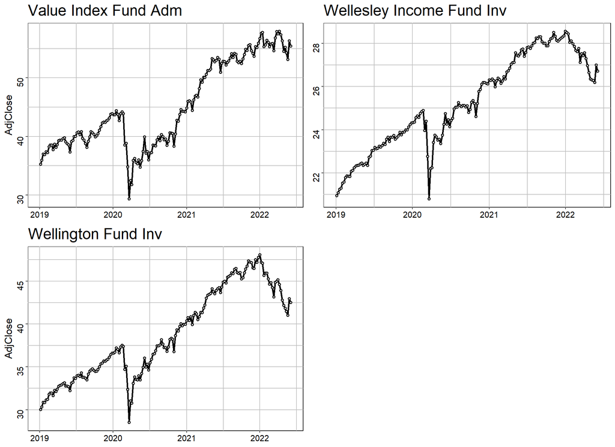

AdjClose Prices for Vanguard Balanced/Income/Value Index Funds

```r
RplotterPkg::multi_scatter_plot(
  df = balanced_dt,
  factor_var = "Title",
  factor_x = "Date",
  aes_y = "AdjClose",
  connect = TRUE,
  col_width = 5.5,
  row_height = 4
)
```

## Bonds Plots

### Define a `data.table` for the bond funds

```r
bond_tickers_v <- c("VBILX","VBIRX")
bond_dt <- prices_dt[Symbol %in% bond_tickers_v,]
bond_dt[, Symbol := factor(Symbol, levels = c("VBILX","VBIRX"))]
bond_dt[, Title := fcase(
                       Symbol == "VBILX", tickers_v[["VBILX"]],
                       Symbol == "VBIRX", tickers_v[["VBIRX"]]
                     )]
bond_dt[, Title := as.factor(Title)]
```

### Plot the bond funds

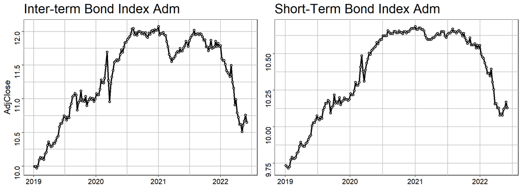

AdjClose Prices for Vanguard Bond Index Funds

```r
RplotterPkg::multi_scatter_plot(
  df = bond_dt,
  factor_var = "Title",
  factor_x = "Date",
  aes_y = "AdjClose",
  connect = TRUE,
  col_width = 5.5,
  row_height = 4
)
```

## Sector-Foreign Plots

### Define the `data.table` for the sector/foreign funds

```r
sector_tickers_v <- c("VGSLX","VGHCX","VFWAX")
sector_dt <- prices_dt[Symbol %in% sector_tickers_v,]
sector_dt[, Symbol := factor(Symbol, levels = c("VGSLX","VGHCX","VFWAX"))]
sector_dt[, Title := fcase(
                       Symbol == "VGSLX", tickers_v[["VGSLX"]],
                       Symbol == "VGHCX", tickers_v[["VGHCX"]],
                       Symbol == "VFWAX", tickers_v[["VFWAX"]]
                     )]
sector_dt[, Title := as.factor(Title)]
```

### Plot the sector/foreign funds

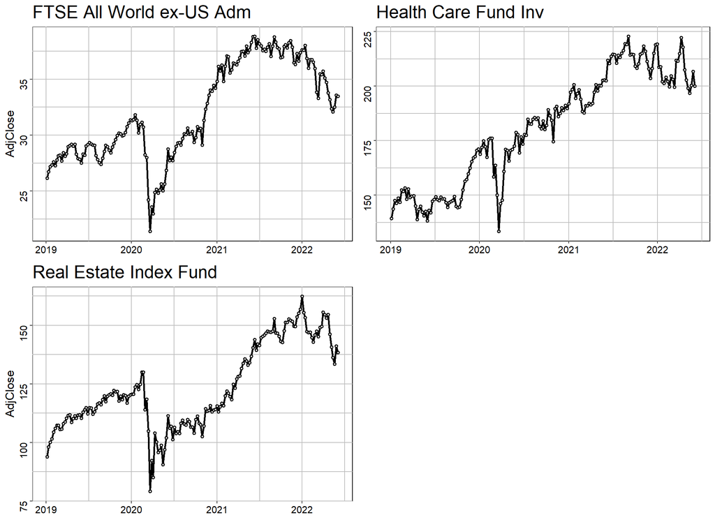

AdjClose Prices for Vanguard Sector/Foreign Index Funds

```r
RplotterPkg::multi_scatter_plot(
  df = sector_dt,
  factor_var = "Title",
  factor_x = "Date",
  aes_y = "AdjClose",
  connect = TRUE,
  col_width = 5.5,
  row_height = 4
)
```